# PSet 4

Chao Pang, Krishna Kalluri

Note: Grading is based both on your graphs and verbal explanations. Follow all best practices *as discussed in class*, including choosing appropriate parameters for all graphs. *Do not expect the assignment questions to spell out precisely how the graphs should be drawn. Sometimes guidance will be provided, but the absense of guidance does not mean that all choices are ok.*

IMPORTANT: THIS TEMPLATE DOES NOT INCLUDE THE SAMPLE GRAPHS THAT APPEAR IN THE .HTML VERSION OF THE ASSIGNMENT SO BE SURE TO VIEW THAT FILE AS WELL.

### 1. `mycars` missing patterns

Create a missing values plot for the `mycars` dataset created below (slightly different from the one in the lecture slides). Your plot should be in the style of `extracat::visna()` (no longer available on CRAN) using **ggplot2** to create the main plot and two side plots and **patchwork** to put them together. It should show accurately: missing patterns, counts for missing by column and missing by pattern, and make it clear which row respresents complete cases. Bars in the side plots should be sorted and correspond to the rows and columns of the main plot. An example is provided though the aesthetics of your plot do not have to conform precisely to the example. Some code is provided to get you started with finding missing patterns. (Keep in mind that in the next question you will be turning this code into a function so to save yourself time later on write as generically as possible.)

```r
library(tidyverse)
library(patchwork)

# Add NAs to mtcars dataset
set.seed(5702)
mycars <- mtcars
mycars[1:25, "gear"] <- NA
mycars[10:20, 3:5] <- NA
for (i in 1:10) mycars[sample(32,1), sample(11,1)] <- NA
```

**Hints:**

- You can use this code to find and count the missing patterns:

```r
missing_patterns <- data.frame(is.na(mycars)) %>%
  group_by_all() %>%
  count(name = "count", sort = TRUE) %>%
  ungroup()
```

- To highlight the complete cases row you need a different fill scale than the one used to show missing vs. non-missing in the main plot (purple and grey in the example). This is a little tricky since you’re only allowed one fill scale in **ggplot2**. You can either use `alpha` to control the highlight with `scale_alpha_manual(values = ...)` or use the **ggnewscale** package which provides for multiple fill scales in the same graph.

```r
num_of_rows <- nrow(mycars)

plots_input <- missing_patterns %>%
  rownames_to_column(var = "id") %>%
  mutate(id = as.integer(id)) %>%
  mutate(id = factor(id))

input_variable_order <- plots_input %>%
  gather(key, value, -c(id, count)) %>%
  group_by(key) %>%
  summarise(variable_count = sum(count * value)) %>%
  arrange(desc(variable_count)) %>%
  mutate(variable_order=row_number())

input_variable_order
```

```
## # A tibble: 11 × 3
##    key   variable_count variable_order
##    <chr>          <int>          <int>
##  1 gear              25              1
##  2 disp              12              2
##  3 hp                12              3
##  4 drat              11              4
##  5 am                 3              5
##  6 cyl                1              6
##  7 qsec               1              7
##  8 vs                 1              8
##  9 carb               0              9
## 10 mpg                0             10
## 11 wt                 0             11
```

Created a input_variable_order data frame by gathering the counts of missing values and added variable_order column by ordering the variable_count descending to use it as a factor to order the variables in the visualization.

```r
pivot_missing_patterns <- plots_input %>%
  gather(key, value, -c(id, count)) %>%
  inner_join(input_variable_order, "key") %>%
  mutate(id = factor(id)) %>%
  mutate(key = fct_reorder(key, variable_order, min))

missing_id <- pivot_missing_patterns %>%
  group_by(id) %>%
  summarise(n_of_missing = sum(value)) %>%
  filter(n_of_missing == 0) %>%
  pull(id)

x_levels <- levels(pivot_missing_patterns$key)

missing_id_x <- x_levels[ceiling((length(x_levels)) / 2)]
missing_id_y <- levels(missing_id)[missing_id]

pivot_missing_patterns <- pivot_missing_patterns %>%
  mutate(value = ifelse(
    id == missing_id_y,
    "Complete",
    ifelse(value, "Missing", "Not missing")
  )) %>%
  mutate(value = factor(value, levels = c("Missing", "Not missing", "Complete")))
```

Created x_levels to use these levels in the visualization to highlight the complete cases in the missing value pattern plot.

```r
p_tile <- ggplot(pivot_missing_patterns, aes(x = key, y = fct_rev(id), fill = value)) +
  geom_tile(color = "white") +
  scale_fill_manual(values = c(
    "Missing" = "#B69FE5",
    "Not missing" = "#CBCBCB",
    "Complete" = "#B3B3B3")) +
  xlab("Variable")  +
  ylab("Missing Pattern") +
  theme(legend.title = element_blank()) +
  theme(legend.position = "none") +
  annotate("text",
           x = missing_id_x,
           y = missing_id_y,
           label = "Complete Case")
```

```r
input_pattern_hist <- plots_input %>%
  select(c(id, count)) %>%
  mutate(is_complete=ifelse(id == missing_id_y, "Complete", "Missing"))

p_pattern_hist <- ggplot(input_pattern_hist,
                         aes(x=fct_rev(id),
                             y=count,
                             fill = is_complete)) +
  geom_bar(stat = "identity") +
  scale_fill_manual(values = c(
    "Missing" = "#97B7F1",
    "Complete" = "#6495EC")) +
  coord_flip() +
  xlab(element_blank())  +
  ylab("row count") +
  theme_bw() +
  theme(
    panel.grid.major.y = element_blank(),
    legend.title = element_blank(),
    legend.position = "none"
  )
```

```r
p_variable_hist <- ggplot(input_variable_order, aes(x=fct_reorder(key, variable_order), y=variable_count)) +
  geom_bar(stat = "identity", fill="#97B7F1") +
  xlab(element_blank())  +
  ylab("num rows missing") +
  theme_bw() +
  theme(
    panel.grid.major.x = element_blank(),
    panel.grid.major.y = element_line( size=.1, color="gray")
  )
```

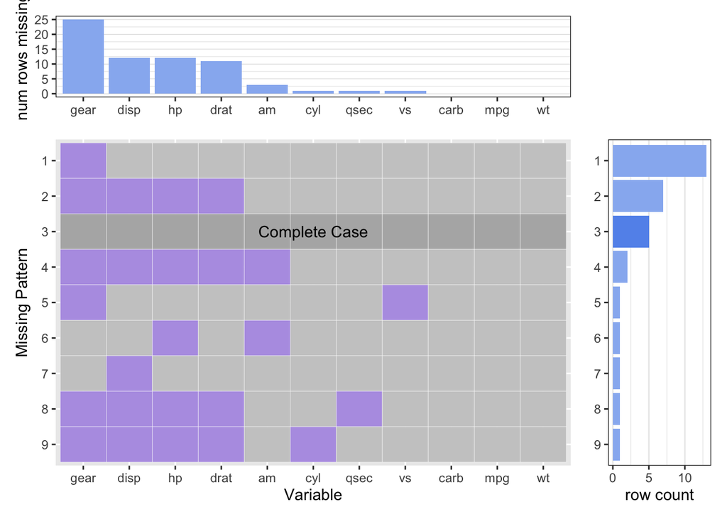

```r
p_variable_hist + plot_spacer() + p_tile + p_pattern_hist +  plot_layout(widths = c(5, 1), heights = c(2, 8))
```

### 2. Missing value plot function

1. Create a function for creating missing plots based on your code from question 1. It should provide an option to show either missing counts or missing percent. The percent option for `mycars` is shown below.

You either put the function code in a separate `.R` file or include it in the `.Rmd` file.

we gathered the code used to generate the missing values pattern plot created a function named `plot_missing` it has been saved as a separate R file so it can me sourced and used in other cases.

`plot_missing` takes in 3 arguments `data`, `percent`, `shortenNames`.

`data` is a required argument which accepts a dataframe as input.

`percent` is a optional argument, if not set to `TRUE` the function generates a missing values plot with counts of missing values. When set True it will generate a missing value pattern plot with % missing values

`shortenNames` is a optional argument as well. if it is not set `TRUE` the function generates plots with full variable names if set to `TRUE` the variable names on the axis will be shortened for visibility.

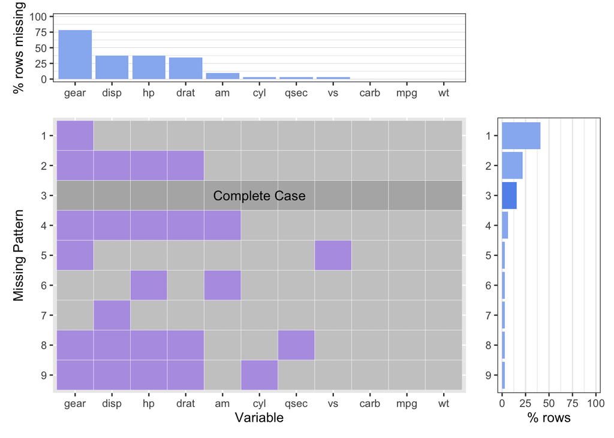

```r
source("plot_missing.R")
plot_missing(mycars, percent=T)
```

2. Show the output for both options (counts / percent) for the `economics` dataset in the **ggplot2** package. (This is a test to see if your function works if there are no missing values.)

#### Economics: Missing Value Pattern - Counts

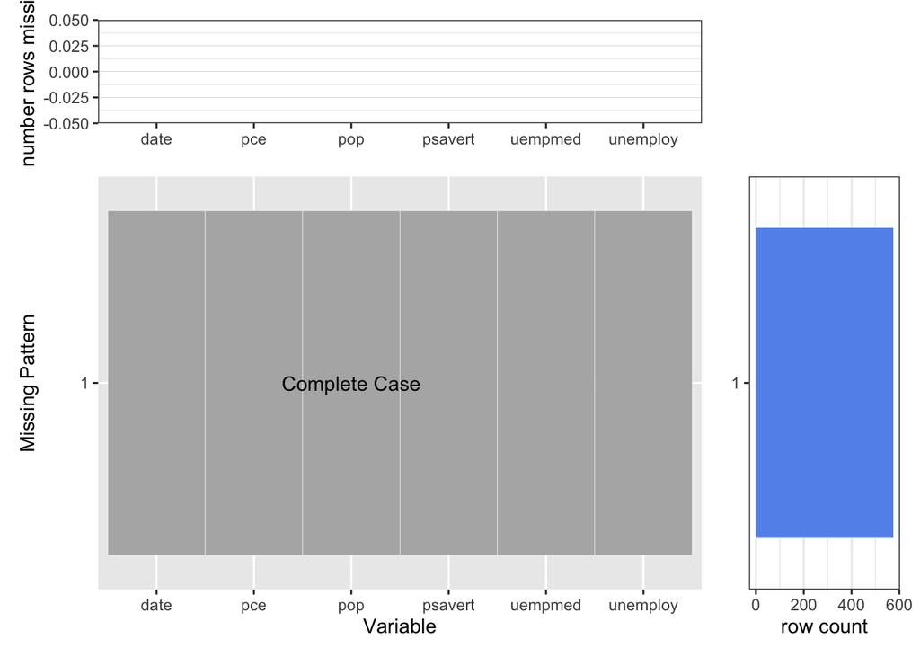

```r
plot_missing(economics)
```

#### Economics: Missing Value Pattern -Percentages

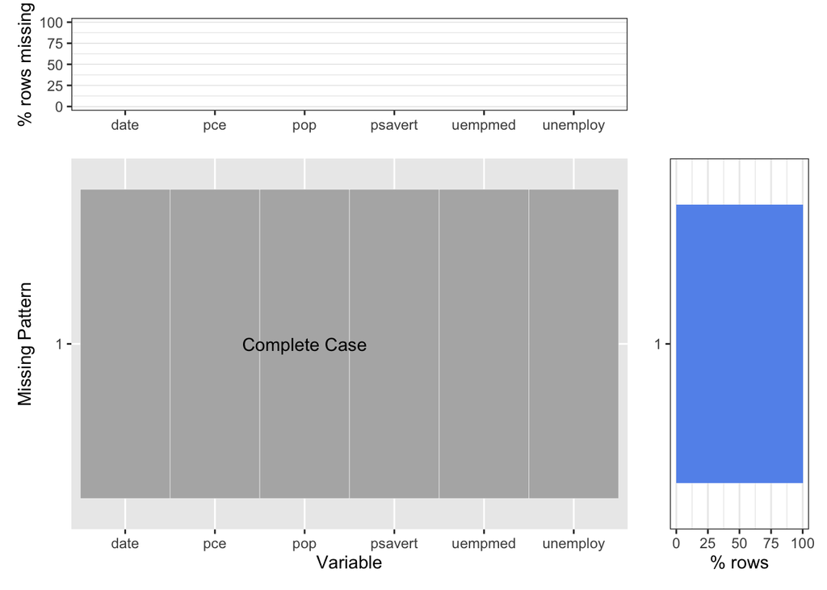

```r
plot_missing(economics, TRUE)
```

3. Show the output for both options (counts / percent) for the `HollywoodMovies2011` dataset in the **Lock5withR** package. You can shorten the column names so they don’t overlap in the plot.

#### HollywoodMovies2011: Missing Value Pattern - Counts(Shortened variable names)

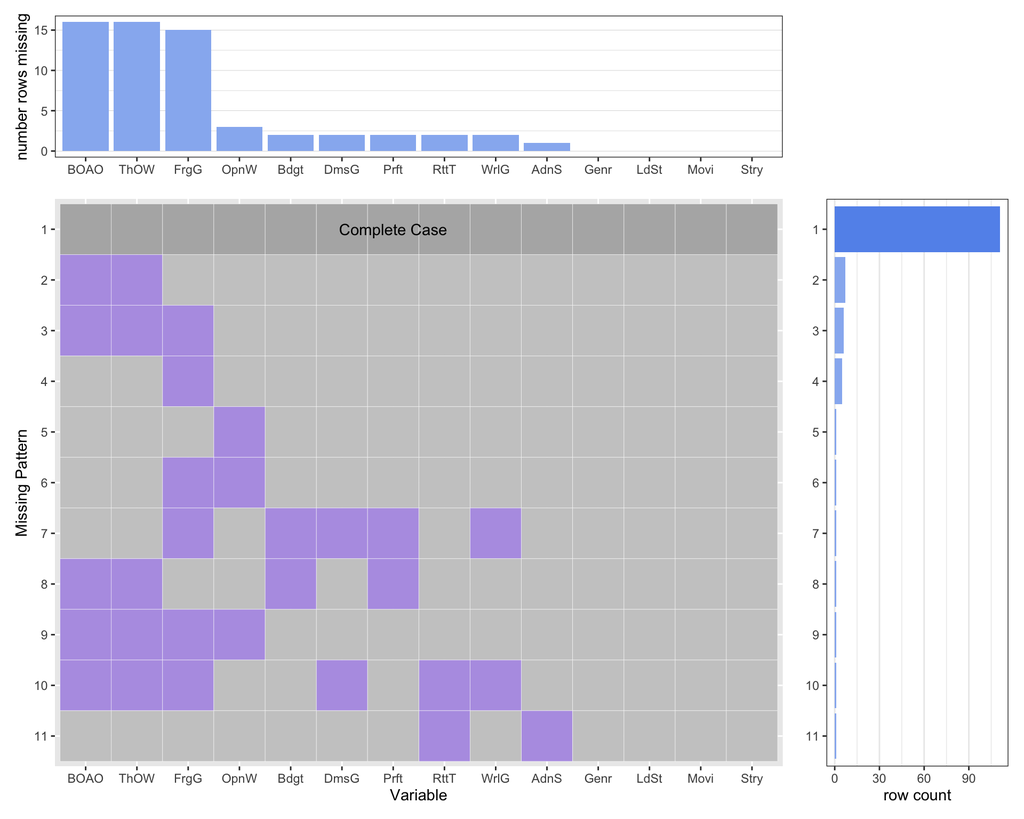

```r
plot_missing(Lock5withR::HollywoodMovies2011, percent=F, shortenNames=T)
```

#### HollywoodMovies2011: Missing Value Pattern - Percentages(Shortened variable names)

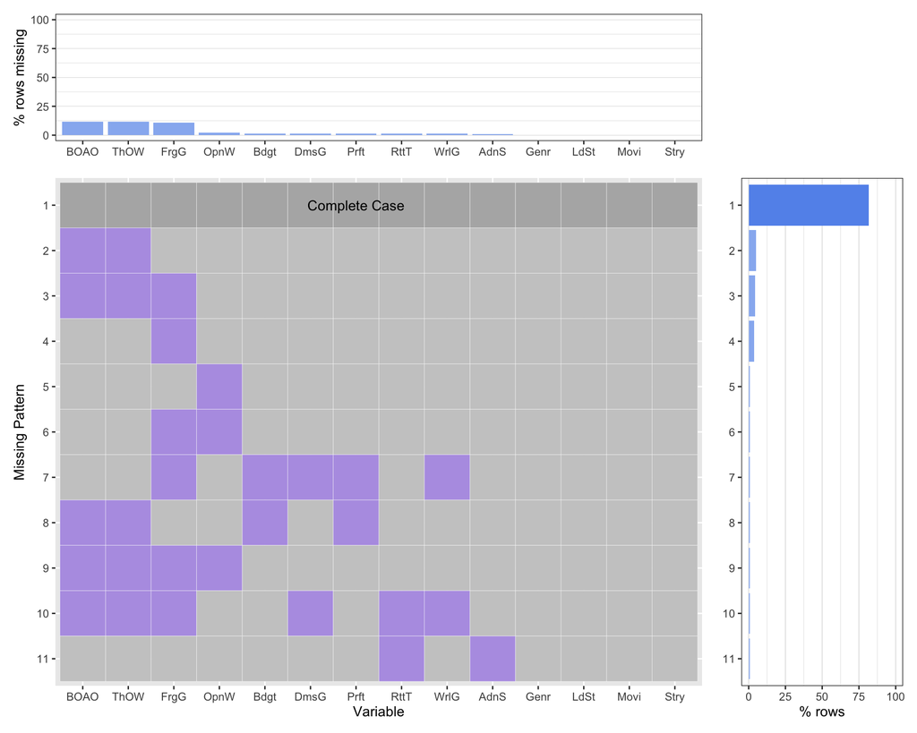

```r
plot_missing(Lock5withR::HollywoodMovies2011, percent=T, shortenNames=T)
```

### 3. Setup your GitHub final project repo

1. Set up your final project repository following the [EDAVproject template](https://github.com/jtr13/EDAVtemplate). You can either choose one team member’s GitHub account, or create an organization to house the final project. *Be sure to follow all of the steps in the README so your bookdown book renders with your information, not the placeholders in the template.* Edit the link below to point to your rendered book:

[Craft Beer Ratings Analysis](https://kkcp-dsi.github.io/CraftBeerRatingsAnalysis/) - https://kkcp-dsi.github.io/CraftBeerRatingsAnalysis/

2. Make sure that all team members have write access to the repository and have practiced making contributions. Edit the link below to point to your contributors page, showing that all team members have made contributions to the repo (Note that we do not have the ability to see who has write access, only who has contributed):

[Contributors](https://github.com/kkcp-dsi/CraftBeerRatingsAnalysis/graphs/contributors) - https://github.com/kkcp-dsi/CraftBeerRatingsAnalysis/graphs/contributors

3. Discuss a plan for dividing up the work for the final project and briefly summarize what each person will do.

We are at the data collection stage currently. Since the inception of the final project, we’ve been web scraping the beer information from untappd periodically including average ratings, number of check-ins, beer style, and etc. This is an ongoing effort that is being carried out by both of us, we are taking turns to web scrape the data.

In addition to that, we are trying to identify the data sources for beer ingredients because preliminary searches conducted for project proposal showed that this type of information is not readily available online.

- Chao will be writing the introduction
- We will both work on data collection
- Krishna will focus on data transformation
- Once we have collected all the data, we will divide the following questions between the two of us
  - Find out if there is any correlation between the location of the brewery and the ratings that a brewery is getting (Krishna)
  - Find out the correlation between ratings and ingredients used in the beer. (Krishna)
  - Find out the correlation between beer styles and the kind of ratings they receive. (Chao)
  - As a bonus question, it would be nice to find out the highly rated styles of beers in each state because it would guide us in hunting the best beers in the future. (Chao)
- We will work on interactive components and conclusion together

### 4. Missing values chapter

Write a first draft of the missing values chapter of your final project. You do not have to include all of the data you use in the final project. Choose one file and analyze it using techniques discussed in class for missing values. Include a plot using your function from Q2 as well as verbal interpretation of the plot. Edit this link to point to your chapter:

**If your data for the final project has no missing values, you may use one of the following datasets instead for this question. You can include your answer here since it doesn’t belong in your final project.**

**fivethirtyeight** package: `avengers`, `bachelorette`, `dem_candidates`, `steak_survey`, `trumpworld_polls`

**openintro** package: `birds`, `ucla_textbooks_f18`

```r
if (!require("fivethirtyeight")) install.packages("fivethirtyeight")
library(fivethirtyeight)
```

The dataset we used for the missing data analysis is **trumpworld_polls**, which is about how the world perceived the US and the US president from 2000 through 2017. There are two separate poll questions, which are “Have a favorable view of the U.S” and “Trust the U.S. President in foreign affairs”. In this dataset, there are 37 countries in which the polls were conducted, it’s worth noting that the “Favorable view” question was not conducted in 2000, 2002, and 2004 and the “Trust president” question was not conducted in 2001, it’s important to point out that we DO NOT consider such cases (where the polls were not conducted at all) as missing value, they were simply not conducted.

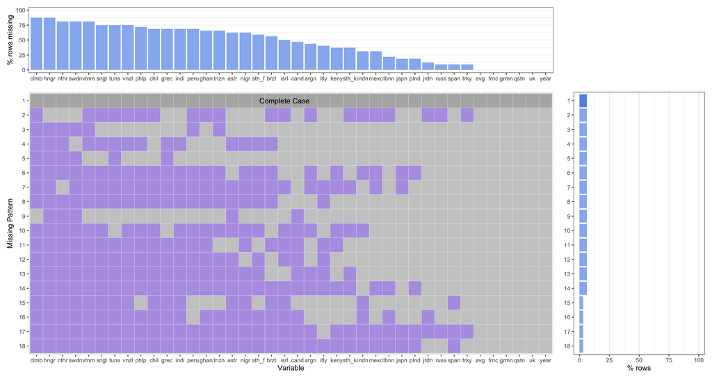

```r
plot_missing(trumpworld_polls, percent = T, shortenNames = T)
```

As the aggregate missing pattern plot shows, there is no missing values in the “common columns” including **year** and **avg**, and **question**. There are missing values in most of the countries, however, there are no missing values in the following countries, France, Germany, and the UK. The top histogram indicates that for those countries that have either close diplomatic relations or competing interests with the US, people seem more likely to answer the polls regarding their opinions about the US and the US president. Interestingly, there is a complete case pattern in the plot, indicating that all the polls have been answered by people across all countries for certain periods, we need to look at this further in the following analyses. To facilitate the interpretation, we make the assumption that the missing value “NA” represents that scenario, where nobody responded to the poll at all in that particular country.

```r
num_missing_by_country_year <- trumpworld_polls %>%
  gather(key="country", value="rating", -c(year, question, avg)) %>%
  mutate(is_rating_missing=is.na(rating))
```

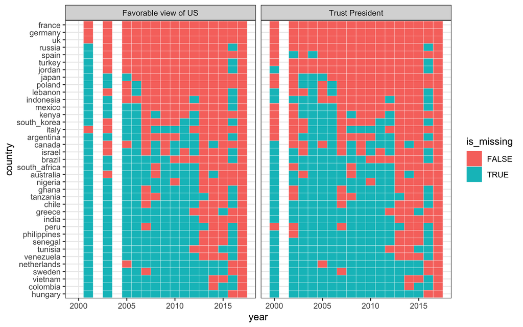

```r
ggplot(num_missing_by_country_year, aes(x=year, y=fct_rev(fct_reorder(country, is_rating_missing, sum)), fill=factor(is_rating_missing))) +
  geom_tile(color="white") +
  theme_bw() +
  facet_wrap(~question) +
  xlab("year") +
  ylab("country") +
  guides(fill=guide_legend(title="is_missing"))
```

We generated the geom_tile plot to indicate missingness by country across year. As stated previously, the polls were not conducted in 2000, 2002 and 2004 for “Favorite view of US” and 2001 for “Trust President”. Based on the pattern presented in the plot, there are more number of missing values in the early years, and the number of missing values gets smaller as time goes on. In particular, there is no missing value in 2017 for both polls, suggesting all people were more likely to answer the polls in this year. Let’s explore whether the number of missing values is associated with the average percentage of people who answered the pool positively, for convenience, we are going to refer to the variable **avg** as positive ratings in the following sections.

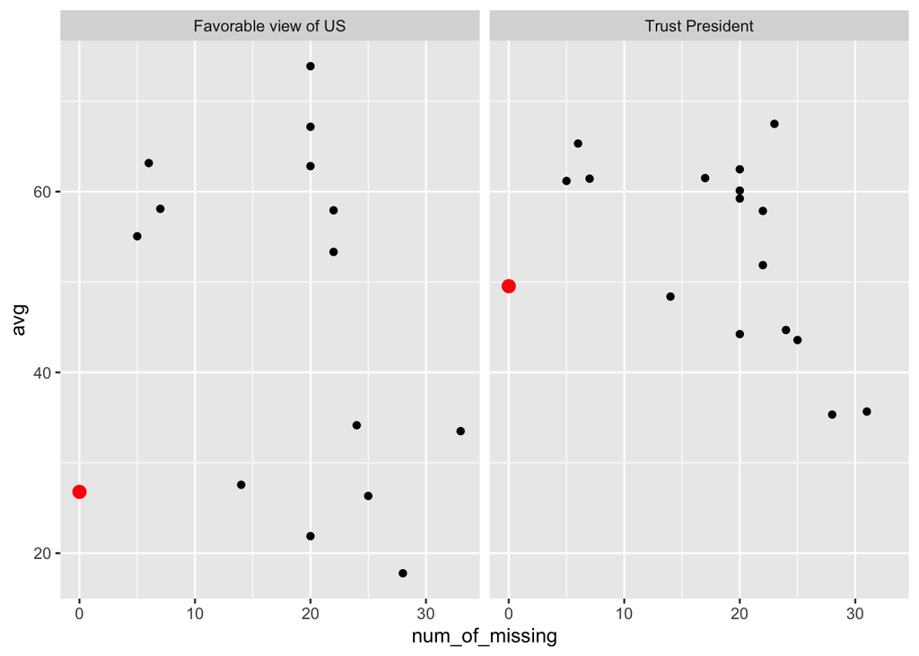

```r
num_missing_scatterplot <- num_missing_by_country_year %>%
  group_by(year, avg, question) %>%
  summarise(num_of_missing=sum(is_rating_missing)) %>%
  ungroup() %>%
  mutate(sitting_president=ifelse(year<=2008, "Bush", ifelse(year<="2016", "Obama", "Trump")))

ggplot(num_missing_scatterplot, aes(x=num_of_missing, y=avg, label=year)) +
  geom_point() +
  geom_point(data = . %>% filter(num_of_missing == 0), size=3, color="red") +
  facet_wrap(~question)
```

Based on the above scatterplot, it seems that the more number of missing values there are, the lower the positive ratings are except for the two two points highlighted in the plots. Let’s take a look at whether the number of missing values and the average positive ratings have anything to do with who was the sitting president.

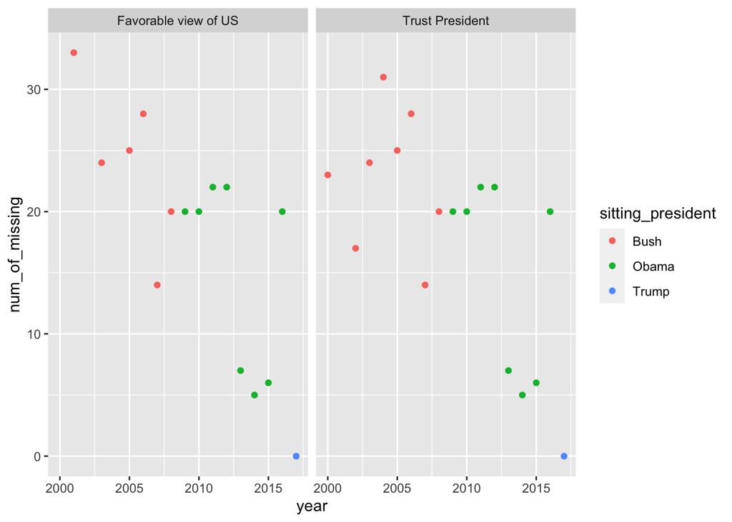

```r
ggplot(num_missing_scatterplot, aes(x=year, y=num_of_missing, color=sitting_president)) +
  geom_point() +
  facet_wrap(~question)
```

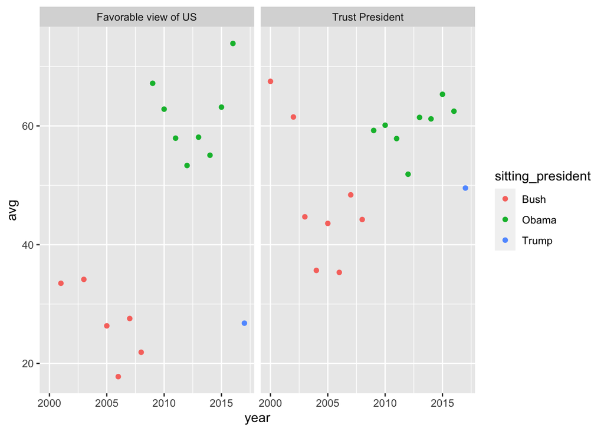

```r
ggplot(num_missing_scatterplot, aes(x=year, y=avg, color=sitting_president)) +
  geom_point() +
  facet_wrap(~question)
```

The scatterplots tell a much better story after color coding the points by sitting president. In general, people didn’t seem to be interested in answering the poll when Bush was the sitting president and his positive ratings were relatively low among all participants. On the other hand, Obama seemed to be more popular in the foreign countries, where people were more likely to answer the poll and his positive ratings were very high compared to that of Bush. Despite Obama’s popularity, there were still countries in which people didn’t respond to the polls at all. Most interestingly, when Trump took office, there was no missing values in any countries and he was the only president that was able to get all countries to respond to the polls, however, his positive ratings were relatively low compared to that of Obama.